# Reproducible Research: Peer Assessment 1

## Setting up Environment

This short section included libraries used in the analysis and creates a function  
used later in the analysis. I have hidden the library loading messages.

```r
# Libraries used in this project
library(readr)
library(lubridate)
library(dplyr)
library(ggplot2)
# Function to convert interval into elapsed minutes
elapsedmin <- function(x){
  e <- ifelse(nchar(x)<=2,paste('00:',x, sep = ""),
              paste(substr(x,1,nchar(x)-2),":",substr(x, nchar(x)-1, nchar(x)), sep = ""))
  e
}
```

## Loading and preprocessing the data

Function read_csv will open the zip file and read the enclosed file. preprocessing steps: * Set NA value in datafram.  
* Load activity data.  
* Add a variable that identifies dates as weekdays and weekends (used later).  
* Format interval string data into hhmm and use hm() later to convert the string into elapsed time.

```r
#
d_activity <- read_csv("activity.zip", col_names = TRUE, na = c("NA"))
weekdays1 <- c('Monday', 'Tuesday', 'Wednesday', 'Thursday', 'Friday')
d_activity$wday <- c('weekend', 'weekday')[(weekdays(d_activity$date) %in% weekdays1)+1L]
d_activity$hhmm <- ifelse(nchar(d_activity$interval)<4,paste0(0,d_activity$interval),d_activity$interval)
```

## What is the median and mean (central tendency) total number of steps taken per day?

Create a dataframe with columns date, day (weekend/weekday), tsteps (total steps) * Aggregate the daily actiity (total steps / day)  
* Calculate and print central tendency (median & mean)  
* Provide a Histograme of total steps/day

```r
a_stepsdays <- aggregate(d_activity$steps, by = list(d_activity$date, d_activity$wday), FUN = sum)
colnames(a_stepsdays) <- c("date", "day", "tsteps")
# Central Tendency
summary(a_stepsdays$tsteps)[3:4]
```

```
##   Median     Mean
## 10765.00 10766.19
```

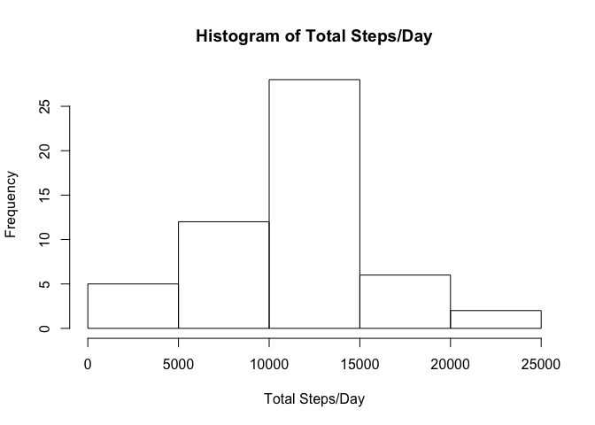

```r
# Histogram of the total number of steps taken each day #####

hist(a_stepsdays$tsteps,
     main = "Histogram of Total Steps/Day",
     xlab = "Total Steps/Day"
     )
```

## What is the average daily activity pattern?

Following plot show daily acitivity averaged over all days (weekdays and weekends).  
* Create a dataframe that averages data across dates to create averages interval data.  
* Create an x-axis based upon elapsed minutes 1435 minutes (0-23:55).

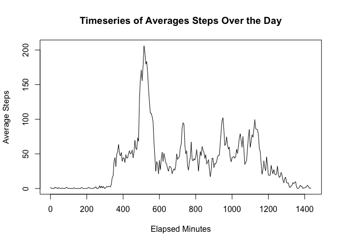

```r
# Average over all days
d_stepsByIntveral <- d_activity %>% group_by(interval) %>% summarize(avgSteps = mean(steps, na.rm = TRUE))
# Elapsed minutes of a day (1435 minutes)
d_stepsByIntveral$telapsed <- hm(elapsedmin(d_stepsByIntveral$interval))
d_stepsByIntveral$elapsed <- hour(d_stepsByIntveral$telapsed)*60 + minute(d_stepsByIntveral$telapsed)

plot(d_stepsByIntveral$elapsed, d_stepsByIntveral$avgSteps, type = "l",
     xlab = "Elapsed Minutes",
     ylab = "Average Steps",
     main = "Timeseries of Averages Steps Over the Day")
```

## Imputing missing values

Code to describe and show a strategy for imputing missing data Assumptions: * Data for all intervals are NA for a ‘missing’ day. * Use a day on either side of a missing day as representitive of the missing day  
* First day of activity measurement is missing - doesn’t completely meet the assumption above.

```r
#Determine index of missing data
i_missing <- which(is.na(a_stepsdays$tsteps))
print(paste("Number of missing days:", length((i_missing))))
```

```
## [1] "Number of missing days: 8"
```

```r
print("List of missing dates: ")
```

```
## [1] "List of missing dates: "
```

```r
a_stepsdays[i_missing,"date"]
```

```
## [1] "2012-10-01" "2012-10-08" "2012-11-01" "2012-11-09" "2012-11-14"
## [6] "2012-11-30" "2012-11-04" "2012-11-10"
```

```r
e_stepsdays <- a_stepsdays
# Rules
# First day is missing - use median of population
for(i in i_missing){
  ifelse(i==1, e_stepsdays[i,3] <- median(e_stepsdays$tsteps, na.rm = TRUE),
        e_stepsdays[i,3] <-
          mean(e_stepsdays[(i-1) : (i+1),3], na.rm = TRUE))
}

# Imputed central tendency
summary(e_stepsdays$tsteps)[3:4]
```

```
##   Median     Mean
## 10765.00 10680.44
```

```r
# Original date central tendency
summary(a_stepsdays$tsteps)[3:4]
```

```
##   Median     Mean
## 10765.00 10766.19
```

## Are there differences in activity patterns between weekdays and weekends?

- Observed differences times of day for activity appear similar between weekday and weekend.
- Summary data suggests the central tendency of activity is higher on the weekend.

```r
d_weekdayInterval <- filter(d_activity, d_activity$wday == "weekday") %>%
  group_by(interval) %>% summarize(avgSteps = mean(steps, na.rm = TRUE))
d_weekdayInterval$wday <- "weekday"
d_weekendInterval <- filter(d_activity, d_activity$wday == "weekend") %>%
  group_by(interval) %>% summarize(avgSteps = mean(steps, na.rm = TRUE))
d_weekendInterval$wday <- "weekend"

summary(d_weekdayInterval$avgSteps)
```

```
##    Min. 1st Qu.  Median    Mean 3rd Qu.    Max.
##   0.000   2.218  23.974  35.338  51.872 234.103
```

```r
summary(d_weekendInterval$avgSteps)
```

```
##    Min. 1st Qu.  Median    Mean 3rd Qu.    Max.
##   0.000   1.107  32.036  43.078  75.571 175.000
```

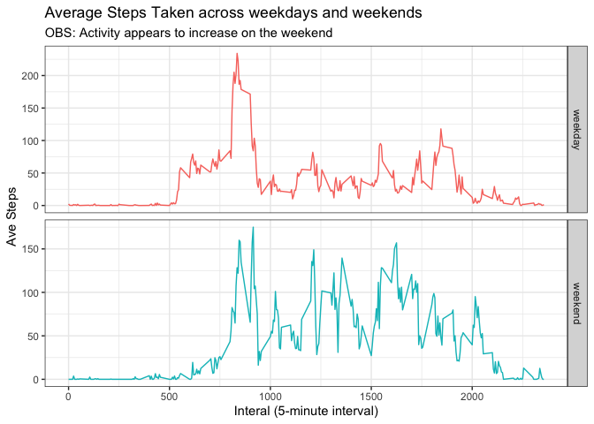

```r
g <- ggplot() + geom_line(data = d_weekdayInterval, aes(x = interval, y = avgSteps, color = "Weekday")) +
     geom_line(data = d_weekendInterval, aes(x = interval, y = avgSteps, color = "Weekend")) +
     facet_grid(wday ~ ., scale = "free_y") + theme_bw() +
     labs(x = "Interal (5-minute interval)", y = "Ave Steps",
       title = "Average Steps Taken across weekdays and weekends",
       subtitle = "OBS: Activity appears to increase on the weekend") +
     theme(legend.position = "none")
print(g)
```